# Reproducible Research Course Project 1

LuisHON

25/08/2020

## Introduction

It is now possible to collect a large amount of data about personal movement using activity monitoring devices such as a Fitbit, Nike Fuelband, or Jawbone Up. These type of devices are part of the “quantified self” movement – a group of enthusiasts who take measurements about themselves regularly to improve their health, to find patterns in their behavior, or because they are tech geeks. But these data remain under-utilized both because the raw data are hard to obtain and there is a lack of statistical methods and software for processing and interpreting the data.

This assignment makes use of data from a personal activity monitoring device. This device collects data at 5 minute intervals through out the day. The data consists of two months of data from an anonymous individual collected during the months of October and November, 2012 and include the number of steps taken in 5 minute intervals each day.

## Data

The data for this assignment can be downloaded from the course web site:

Dataset: Activity monitoring data [52K] The variables included in this dataset are:

steps: Number of steps taking in a 5-minute interval (missing values are coded as NA)

date: The date on which the measurement was taken in YYYY-MM-DD format

interval: Identifier for the 5-minute interval in which measurement was taken

The dataset is stored in a comma-separated-value (CSV) file and there are a total of 17,568 observations in this dataset.

## Assignment

This assignment will be described in multiple parts. You will need to write a report that answers the questions detailed below. Ultimately, you will need to complete the entire assignment in a single R markdown document that can be processed by knitr and be transformed into an HTML file.

Throughout your report make sure you always include the code that you used to generate the output you present. When writing code chunks in the R markdown document, always use echo = TRUE so that someone else will be able to read the code. This assignment will be evaluated via peer assessment so it is essential that your peer evaluators be able to review the code for your analysis.

For the plotting aspects of this assignment, feel free to use any plotting system in R (i.e., base, lattice, ggplot2)

Fork/clone the GitHub repository created for this assignment. You will submit this assignment by pushing your completed files into your forked repository on GitHub. The assignment submission will consist of the URL to your GitHub repository and the SHA-1 commit ID for your repository state.

NOTE: The GitHub repository also contains the dataset for the assignment so you do not have to download the data separately.

#### Loading and preprocessing the data

Loading libraries

```r
# to show all the code
knitr::opts_chunk$set(warning=FALSE)
```

```r
# to load more than one package at time
library(easypackages)
```

```r
# libraries()
libraries("readr", "dplyr", "lattice")
```

```
## All packages loaded successfully
```

Loading the dataset

```r
# unzip the original file
RawFileZip = "repdata_data_activity.zip"
unzip(RawFileZip)
```

```r
# Load the data to a dataframe
data = read.csv(file = "activity.csv", header = TRUE, sep = ",")
```

Analysing the dataset structure

```r
# view the structure of the dataframe
str(data)
```

```
## 'data.frame':    17568 obs. of  3 variables:
##  $ steps   : int  NA NA NA NA NA NA NA NA NA NA ...
##  $ date    : chr  "2012-10-01" "2012-10-01" "2012-10-01" "2012-10-01" ...
##  $ interval: int  0 5 10 15 20 25 30 35 40 45 ...
```

```r
# view the first 6 observations of the dataframe
head(data)
```

```
##   steps       date interval
## 1    NA 2012-10-01        0
## 2    NA 2012-10-01        5
## 3    NA 2012-10-01       10
## 4    NA 2012-10-01       15
## 5    NA 2012-10-01       20
## 6    NA 2012-10-01       25
```

Changing the column *date* **chr** type to a **date** type

```r
# converting the date column to date format
data$date = as.Date(data$date, format = "%Y-%m-%d")
```

#### 1. What is mean total number of steps taken per day?

This part of the assignment, you can **ignore** the missing values in the dataset. Calculate the total number of steps taken per day

```r
# calculating the total number of steps per day
total_perDay_NA =
          aggregate(x = data$steps,
                    by = list(data$date),
                    FUN = sum)

# renaming the columns
names(total_perDay_NA) = c("date", "total_steps")
```

If you do not understand the difference between a histogram and a barplot, research the difference between them.

Make a histogram of the total number of steps taken each day

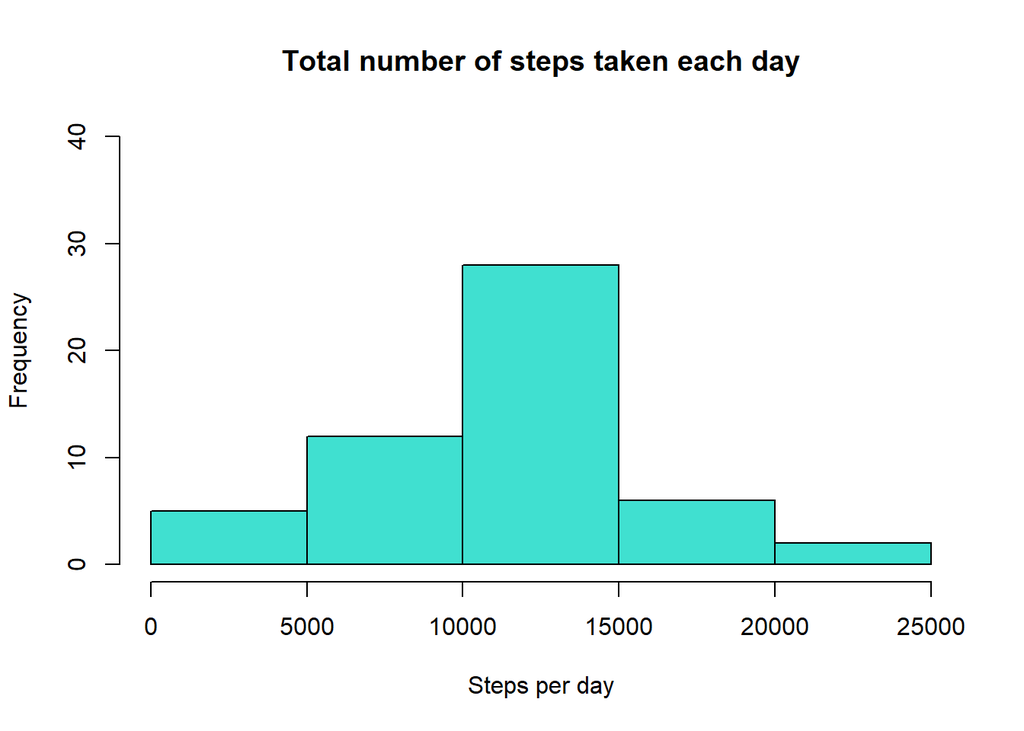

```r
hist(total_perDay_NA$total_steps,
     ylim = c(0,40),
     main = "Total number of steps taken each day",
     xlab = "Steps per day",
     col = "turquoise",
)
```

Calculate and report the mean and median of the total number of steps taken per day

```r
# calculating the mean of the total number steps taken per day
MeanSteps = mean(total_perDay_NA$total_steps, na.rm = TRUE)

MeanSteps
```

```
## [1] 10766.19
```

```r
# calculating the median of the total number steps taken per day
MedianSteps = median(total_perDay_NA$total_steps, na.rm = TRUE)

MedianSteps
```

```
## [1] 10765
```

#### 2. What is the average daily activity pattern?

Make a time series plot (i.e. *type* = “**l**”) of the 5-minute interval and the average number of steps taken, averaged across all days (y-axis)

```r
# obtaining the average number of steps by all days
average_dailyPatern =
     aggregate(x = data$steps,
               by = list(data$interval),
               FUN = mean,
               na.rm = TRUE)

# renaming the columns
names(average_dailyPatern) = c("interval", "average_steps")
```

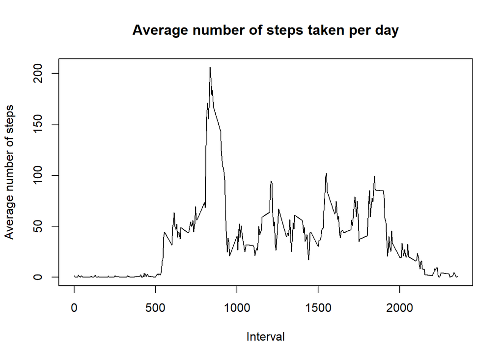

```r
plot(average_dailyPatern$interval,
     average_dailyPatern$average_steps,
     type = "l",
     xlab = "Interval",
     ylab = "Average number of steps",
     main = "Average number of steps taken per day"
)
```

#### 3. Which 5-minute interval, on average across all the days in the dataset, contains the maximum number of steps?

**Imputing missing values**

Note that there are a number of days/intervals where there are missing values (coded as NA). The presence of missing days may introduce bias into some calculations or summaries of the data.

```r
# the which.max() function gives the indice of the max number
maximumNumberSteps = average_dailyPatern[which.max(average_dailyPatern$average_steps), ]

# maximum number of steps
maximumNumberSteps$interval
```

```
## [1] 835
```

Calculate and report the total number of missing values in the dataset (i.e. the total number of rows with NAs)

```r
# total number of missing values
total_numberNA = sum(is.na(data$steps))
total_numberNA
```

```
## [1] 2304
```

Devise a strategy for filling in all of the missing values in the dataset. The strategy does not need to be sophisticated. For example, you could use the mean/median for that day, or the mean for that 5-minute interval, etc.

```r
# replacing missing values by the mean number of steps per Interval
meanValue = mean(average_dailyPatern$average_steps)
meanValue
```

```
## [1] 37.3826
```

```r
# A new dataset equal to the original but with the missing data filled in
newData = data

# analysing the new dataset
head(newData)
```

```
##   steps       date interval
## 1    NA 2012-10-01        0
## 2    NA 2012-10-01        5
## 3    NA 2012-10-01       10
## 4    NA 2012-10-01       15
## 5    NA 2012-10-01       20
## 6    NA 2012-10-01       25
```

```r
# finding the indices with NA
newNA = which(is.na(newData$steps))

# filling the NA's with the mean value
newData$steps[newNA] = meanValue

# analysing the new dataset
head(newData)
```

```
##     steps       date interval
## 1 37.3826 2012-10-01        0
## 2 37.3826 2012-10-01        5
## 3 37.3826 2012-10-01       10
## 4 37.3826 2012-10-01       15
## 5 37.3826 2012-10-01       20
## 6 37.3826 2012-10-01       25
```